# Bayesian Analysis of Rent Prices in Indian cities

### Convergence Diagnostics

For the evaluation of the MCMC convergence Traceplot, density plots, autocorrelation, R-hat and ESS from the model summary were used, as for the previous models.

*Traceplot*

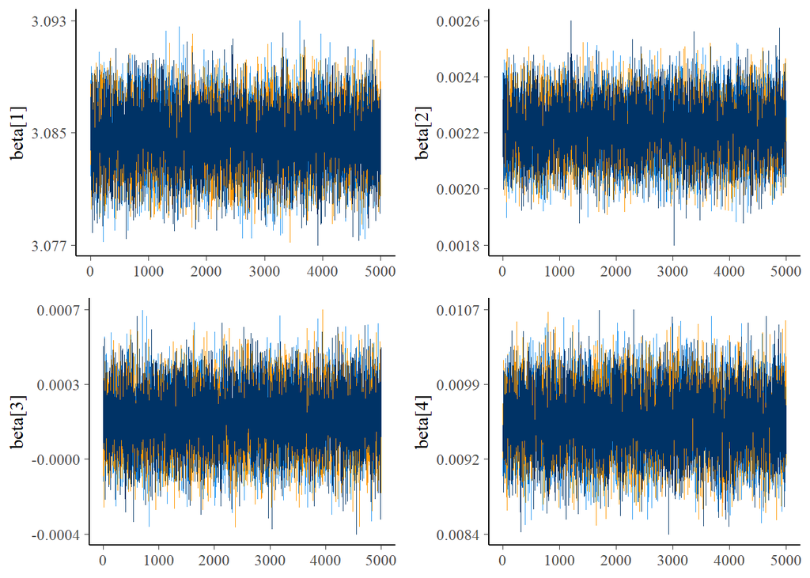

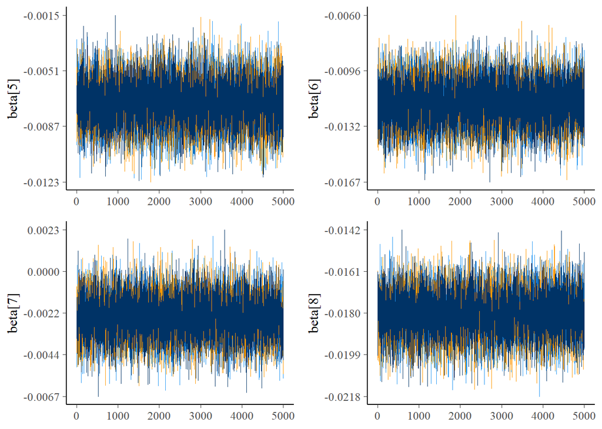

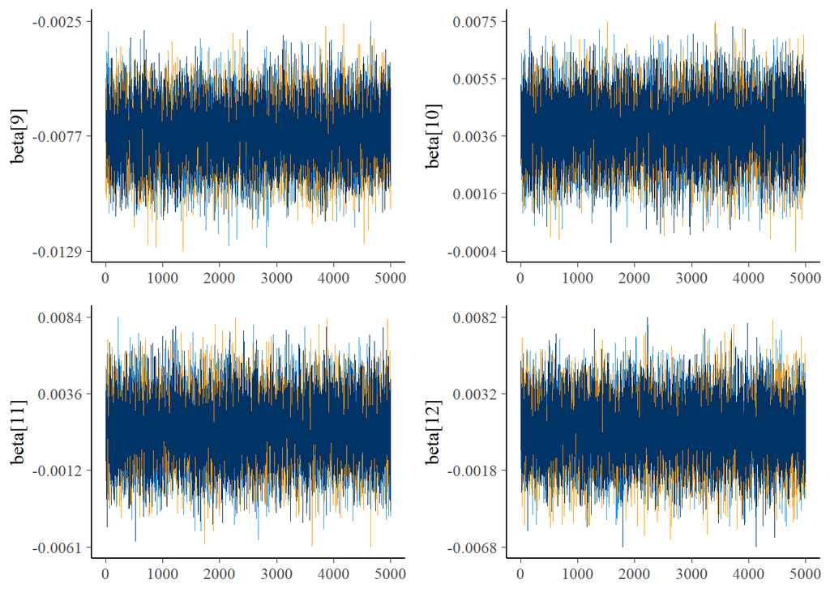

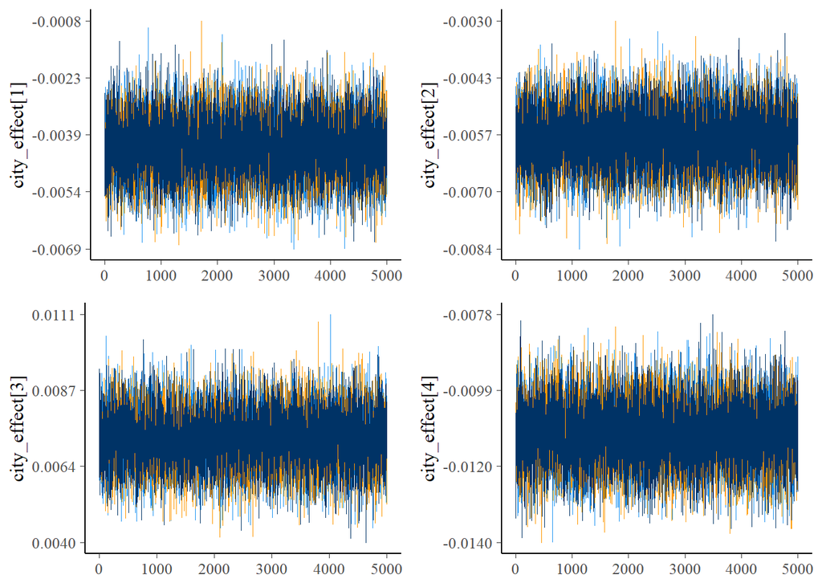

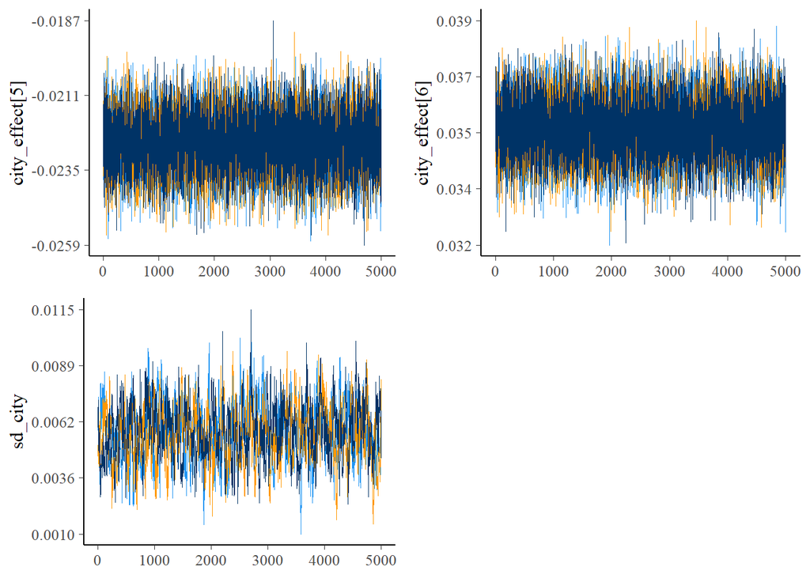

```r
# Convert samples to matrix
samples_matrix <- as.matrix(samples_diag)
all_params <- colnames(samples_matrix)

# Select only relevant parameters for traceplot
params <- all_params[grepl("beta|sd_city|city_effect", all_params)]
chain_colors <- c("#2196F3", "#ff9800", "#003366")

# Plot traceplots
for (i in seq(1, length(params), by = 4)) {
  end <- min(i + 3, length(params))
  param_subset <- params[i:end]

  traceplot <- mcmc_trace(samples_diag, pars = param_subset) + scale_color_manual(values = chain_colors) + theme(legend.position = "none")
  print(traceplot)
}
```

The conclusions we can draw from these traceplots are consistent with the previous models. In the final model, the trace plots show well-mixed and stationary chains, indicating good convergence and reliable posterior sampling.

*Density plot*

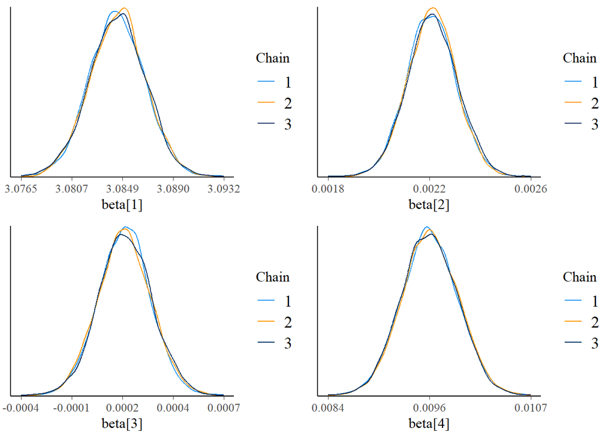

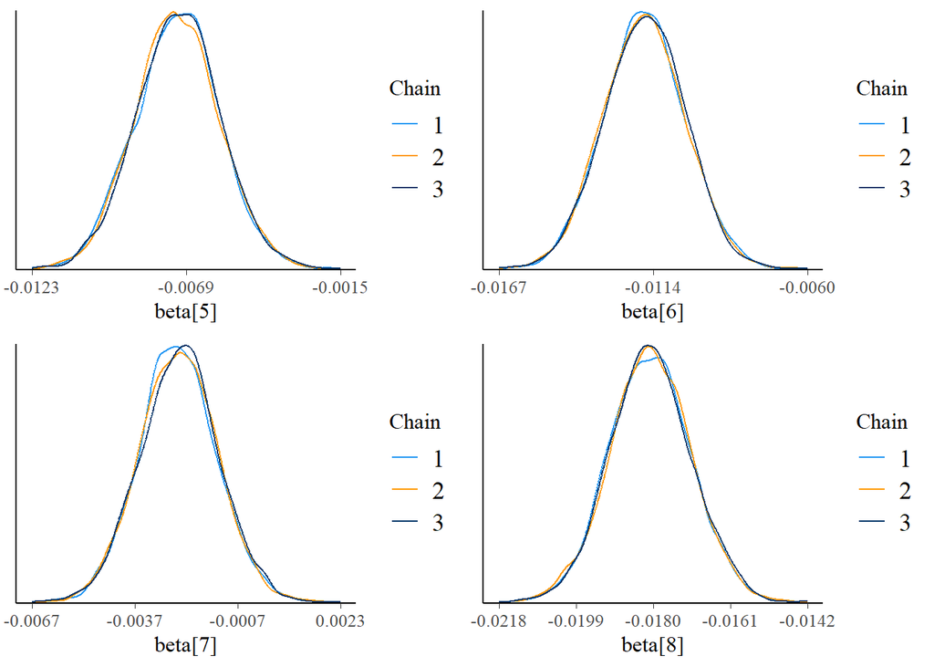

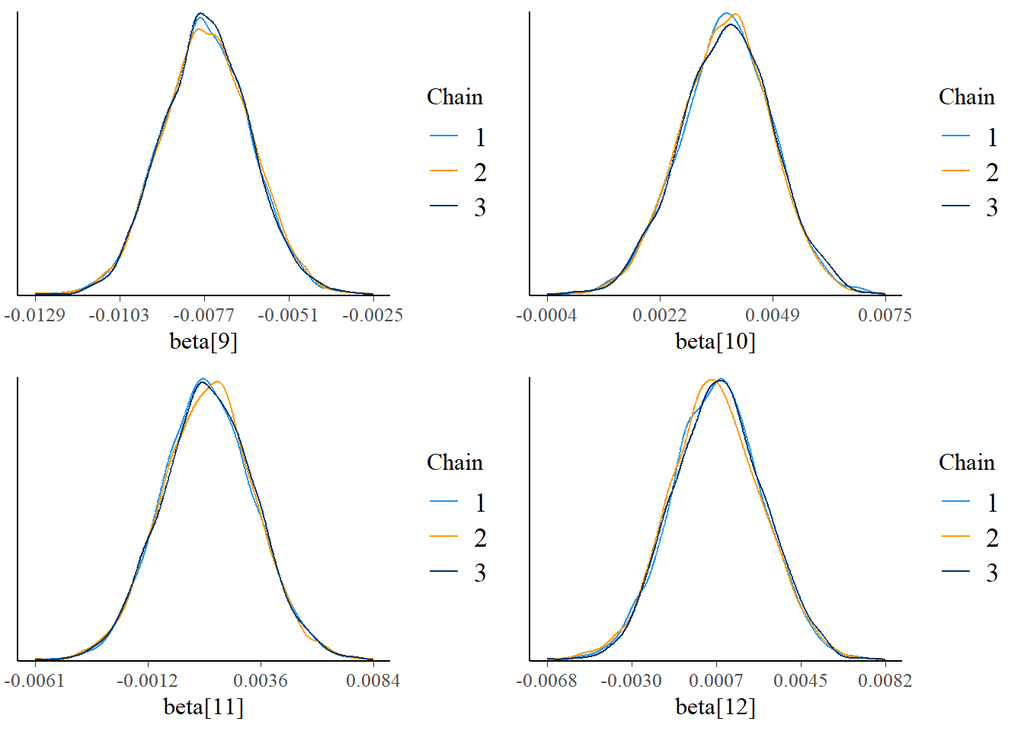

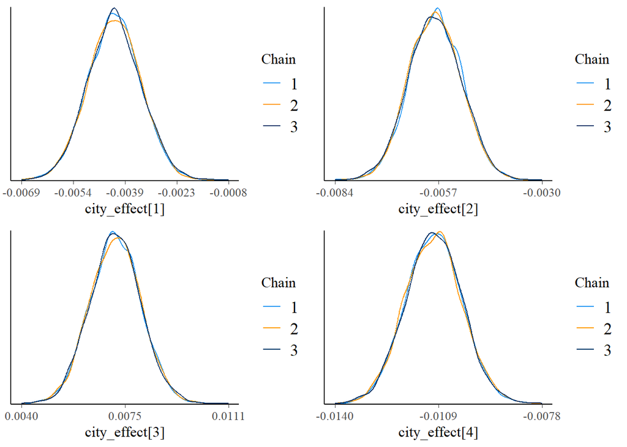

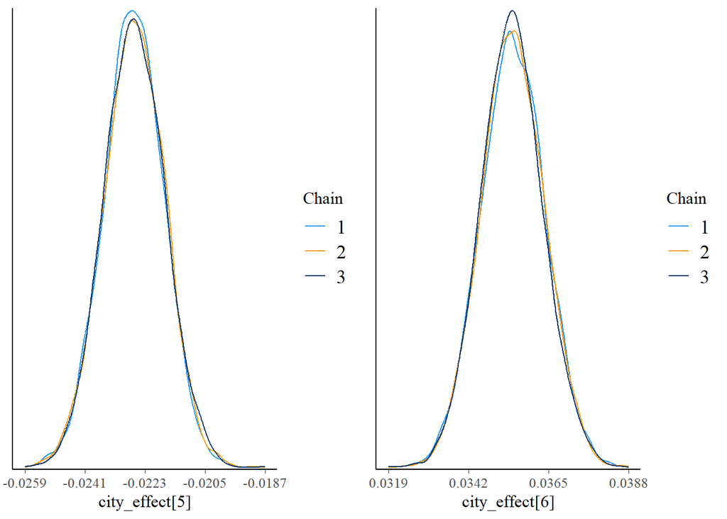

```r
params2 <- all_params[grepl("beta|city_effect", all_params)]

# Plotting Density plots
for (i in seq(1, length(params2), by = 4)) {
  end <- min(i + 3, length(params2))
  param_subset <- params2[i:end]

  density_plot <- mcmc_dens_overlay(samples_diag, pars = param_subset) + scale_color_manual(values = chain_colors)
  print(density_plot)
}
```

In the final model as well, the density plots show that all three MCMC chains converge to nearly identical normal-shaped distributions, indicating stable and consistent parameter convergence.

*Autocorrelation plot*

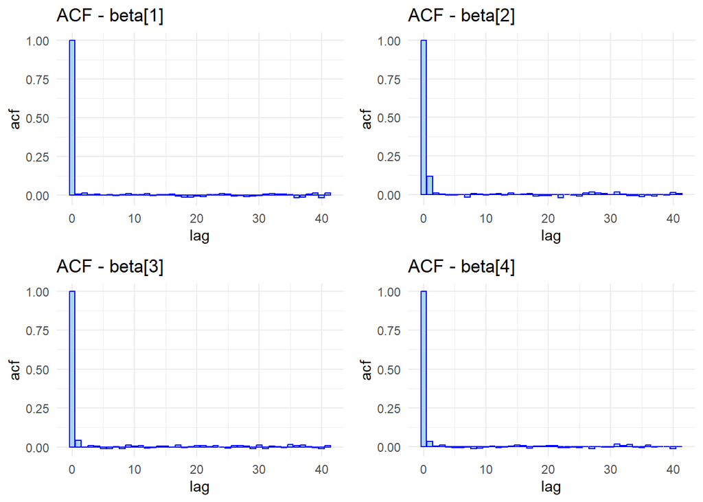

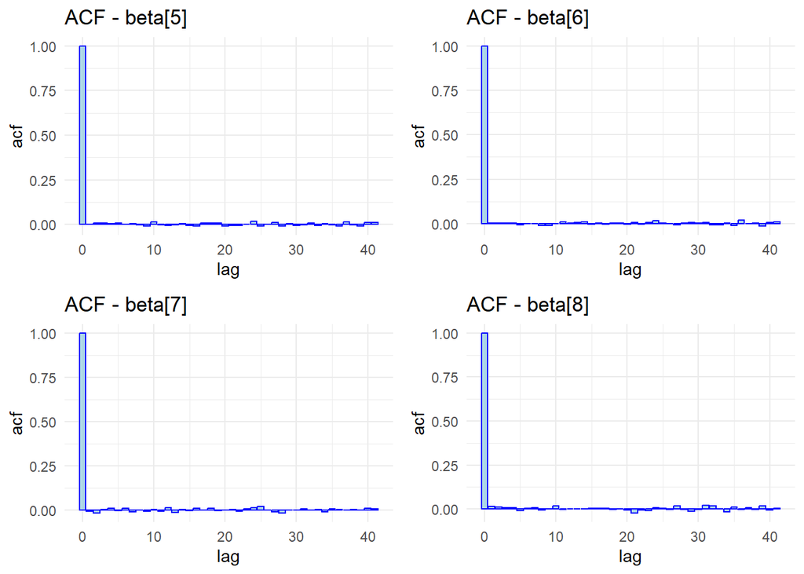

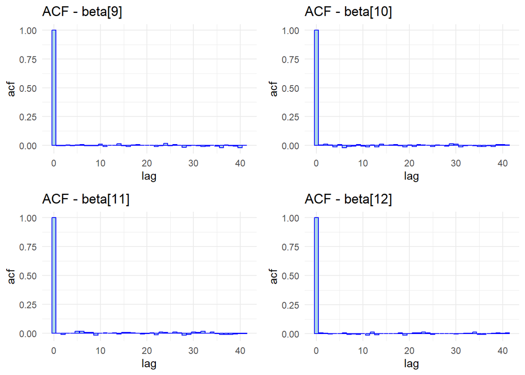

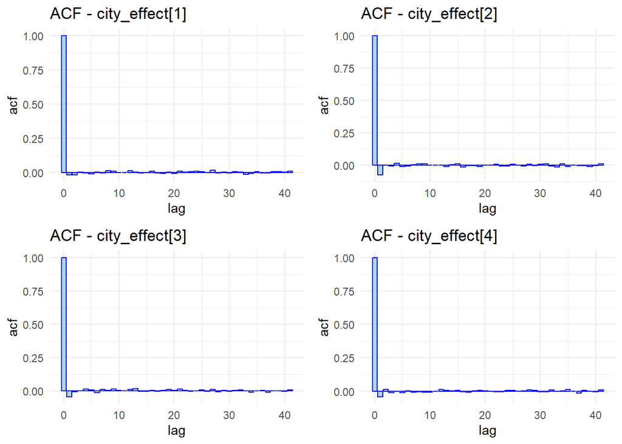

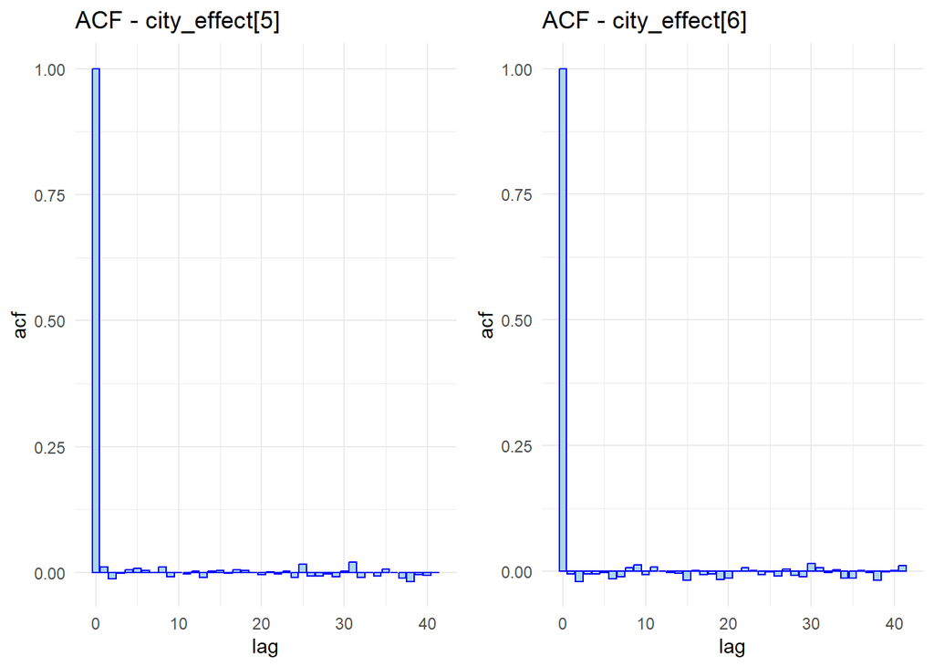

```r
samples_matrix <- as.matrix(sample_diag)

# Plorring Autocorrelation
for (i in seq(1, length(params2), by = 4)) {
  end <- min(i + 3, length(params2))
  param_subset <- params2[i:end]

  plots <- list()

  for (p in param_subset) {
    p_samples <- samples_matrix[, p]
    acf_vals <- acf(p_samples, plot = FALSE)
    acf_df <- with(acf_vals, data.frame(lag, acf))

    g <- ggplot(acf_df, aes(x = lag, y = acf)) +
      geom_bar(stat = "identity", fill = "lightblue", color = "blue") +
      labs(title = paste("ACF -", p)) +
      theme_minimal(base_size = 11)

    plots[[p]] <- g
  }

  grid.arrange(grobs = plots, ncol = 2)
}
```

In the final model as well, the autocorrelation drops off rapidly across all parameters, indicating chains are mixing very efficiently and that the samples are nearly independent, like the previous models.

**ESS and R-Hat**

Finally, we measure the ESS and R-Hat for the final model.

```r
samples_matrix <- as.matrix(sample_diag)

posterior_samples <- as_draws_df(samples_matrix)

# Print only the relevant stats for convergence analysis
summary_stats <- summarize_draws(posterior_samples, "rhat", "ess_bulk", "ess_tail")

print(summary_stats, n = Inf)
```

```
## # A tibble: 20 × 4
##    variable        rhat ess_bulk ess_tail
##    <chr>          <dbl>    <dbl>    <dbl>
##  1 beta[1]         1.00   14279.   14569.
##  2 beta[2]         1.00   11858.   12817.
##  3 beta[3]         1.00   13588.   14306.
##  4 beta[4]         1.00   13637.   13741.
##  5 beta[5]         1.00   14079.   14333.
##  6 beta[6]         1.00   14661.   14669.
##  7 beta[7]         1.00   15213.   14776.
##  8 beta[8]         1.00   13978.   14489.
##  9 beta[9]         1.00   15120.   15067.
## 10 beta[10]        1.00   14345.   14514.
## 11 beta[11]        1.00   14943.   14702.
## 12 beta[12]        1.00   14775.   14350.
## 13 city_effect[1]  1.00   15587.   14701.
## 14 city_effect[2]  1.00   17728.   14864.
## 15 city_effect[3]  1.00   16550.   15367.
## 16 city_effect[4]  1.00   16350.   14541.
## 17 city_effect[5]  1.00   14673.   14686.
## 18 city_effect[6]  1.00   15149.   15239.
## 19 sd_city         1.00     492.    1361.
## 20 sigma_obs       1.00    9667.    9146.
```

# Bayesian Models Comparison

Now, we proceed to compare the performance and predictive accuracy of the three models.

## DIC Comparison

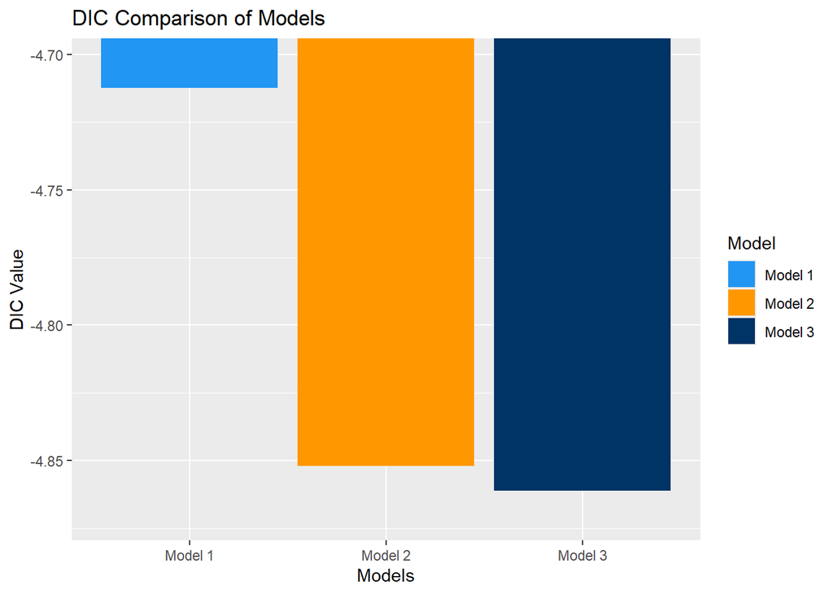

```r
# Create dataframe of DIC values
dic_data <- data.frame(
  Model = c("Model 1", "Model 2", "Model 3"),
  DIC = c(dic_1, dic_2, dic_3)
)

names(chain_colors) <- dic_data$Model

ggplot(dic_data, aes(x = Model, y = DIC, fill = Model)) +
  geom_bar(stat = "identity") +
  scale_fill_manual(values = chain_colors) +
  coord_cartesian(ylim = c(min(dic_data$DIC) - 0.01, max(dic_data$DIC) + 0.01)) +
  labs(
    title = "DIC Comparison of Models",
    x = "Models",
    y = "DIC Value"
  )
```

```r
cat("Model 1 DIC:", round(dic_1, 5), "\n", "Model 2 DIC:", round(dic_2, 5), "\n","Model 3 DIC:", round(dic_3, 5), "\n")
```

```
## Model 1 DIC: -4.71246
##  Model 2 DIC: -4.85196
##  Model 3 DIC: -4.86107
```

All three DIC values are negative, indicating good overall model fit. We observe a substantial improvement from the first to the second model, followed by only a marginal improvement between the second and the third model.

## PPC comparison

We also compare the PPC across the three models.

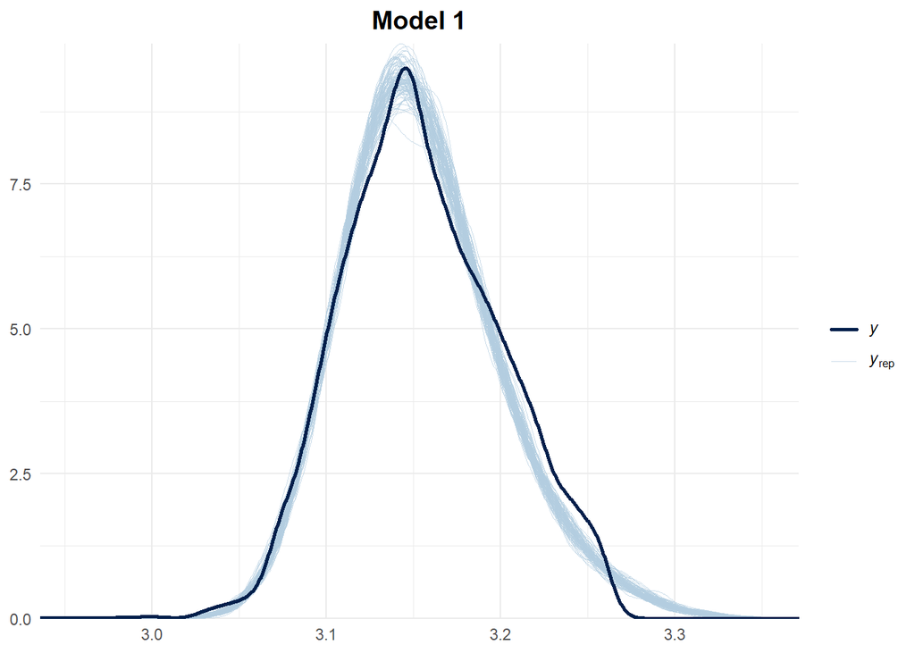

```r
# Model 1
ppc_1 +
  ggtitle("Model 1") +
  theme(plot.title = element_text(size = 14, face = "bold", hjust = 0.5))
```

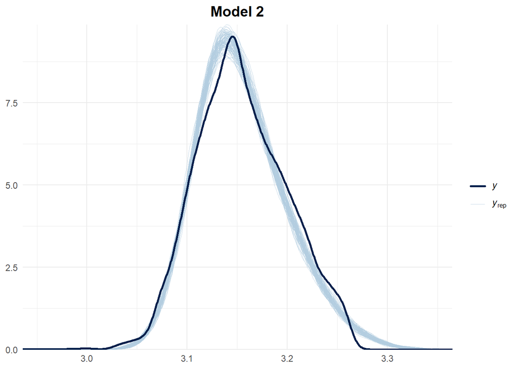

```r
# Model 2
ppc_2 +
  ggtitle("Model 2") +
  theme(plot.title = element_text(size = 14, face = "bold", hjust = 0.5))
```

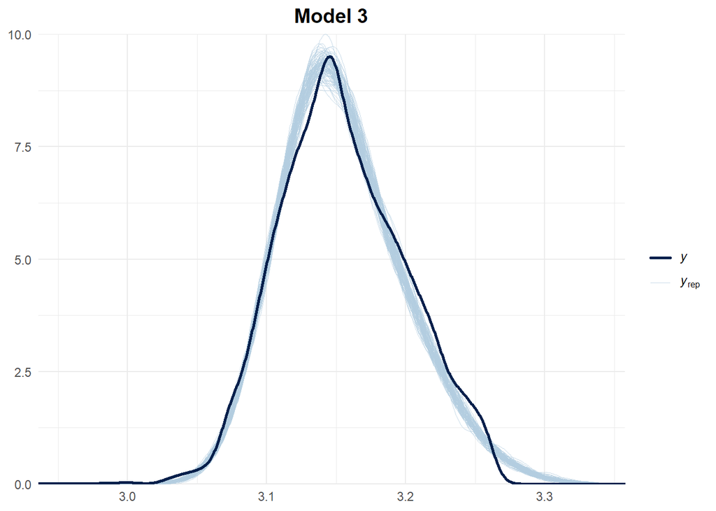

```r
# Final Model
ppc_3 +
  ggtitle("Model 3") +
  theme(plot.title = element_text(size = 14, face = "bold", hjust = 0.5))
```

Over the course of the models, we observe a clear improvement in the upper tail of the rent distribution, where earlier models tended to underpredict, in particular from 3.15 to 3.25. There has been also a slight improvement around the central region of the distribution (approximately at ≈ 3.12).

Despite their differences, all models appear to fit the data reasonably well.

Based on the overall predictive performance and model diagnostics, **we selected the third model for parameter estimation** and **comparison with the corresponding Frequentist model**.

## Credible Intervals and interpretation of results

We now use the third model to analyze the statistical results obtained from the posterior distribution of the coefficients to assess the relationship between the target variable *Rent* and the predictor variables.

```r
samples_matrix <- as.matrix(samples_diag)

beta_samples <- samples_matrix[, grep("^beta\\[", colnames(samples_matrix))]

real_names <- c(
  "Intercept", "Size_bc", "Floor", "RoomsTotal",
  "Furnishing1", "Furnishing2", "Tenant2", "Contact1",
  "OwnerLowQuality", "Is_HighFloor", "Furnished_Big", "AgentFurnished"
)

summary_table <- data.frame(
  Parameter = real_names,
  Mean = apply(beta_samples, 2, mean),
  SD = apply(beta_samples, 2, sd),
  q2.5 = apply(beta_samples, 2, quantile, probs = 0.025),
  q25 = apply(beta_samples, 2, quantile, probs = 0.25),
  q50 = apply(beta_samples, 2, quantile, probs = 0.50),
  q75 = apply(beta_samples, 2, quantile, probs = 0.75),
  q97.5 = apply(beta_samples, 2, quantile, probs = 0.975)
)


# Create and style the table of results
kable(summary_table, format = "html", caption = "Summary of JAGS Model Output") %>%
  kable_styling(bootstrap_options = c("striped", "hover", "condensed", "responsive"))
```

Summary of JAGS Model Output

|  | Parameter | Mean | SD | q2.5 | q25 | q50 | q75 | q97.5 |
| --- | --- | --- | --- | --- | --- | --- | --- | --- |
| beta[1] | Intercept | 3.0856507 | 0.0024379 | 3.0806603 | 3.0840444 | 3.0856992 | 3.0873320 | 3.0902316 |
| beta[2] | Size_bc | 0.0021806 | 0.0001090 | 0.0019518 | 0.0021123 | 0.0021863 | 0.0022548 | 0.0023800 |
| beta[3] | Floor | 0.0001904 | 0.0001418 | -0.0000867 | 0.0000944 | 0.0001910 | 0.0002880 | 0.0004608 |
| beta[4] | RoomsTotal | 0.0095157 | 0.0003267 | 0.0088875 | 0.0092920 | 0.0095102 | 0.0097290 | 0.0101825 |
| beta[5] | Furnishing1 | -0.0070645 | 0.0015246 | -0.0100010 | -0.0081245 | -0.0070849 | -0.0060206 | -0.0040102 |
| beta[6] | Furnishing2 | -0.0114608 | 0.0015581 | -0.0144693 | -0.0125381 | -0.0114862 | -0.0103966 | -0.0083416 |
| beta[7] | Tenant2 | -0.0024478 | 0.0010649 | -0.0045176 | -0.0031585 | -0.0024472 | -0.0017293 | -0.0003440 |
| beta[8] | Contact1 | -0.0181363 | 0.0009148 | -0.0199513 | -0.0187596 | -0.0181287 | -0.0175161 | -0.0163469 |
| beta[9] | OwnerLowQuality | -0.0078001 | 0.0013109 | -0.0103699 | -0.0086879 | -0.0077948 | -0.0069124 | -0.0052227 |
| beta[10] | Is_HighFloor | 0.0035644 | 0.0009738 | 0.0016425 | 0.0029030 | 0.0035758 | 0.0042289 | 0.0054457 |
| beta[11] | Furnished_Big | 0.0003373 | 0.0017376 | -0.0030713 | -0.0008185 | 0.0003423 | 0.0015064 | 0.0037942 |
| beta[12] | AgentFurnished | 0.0017715 | 0.0018415 | -0.0018512 | 0.0005393 | 0.0017704 | 0.0030051 | 0.0054071 |

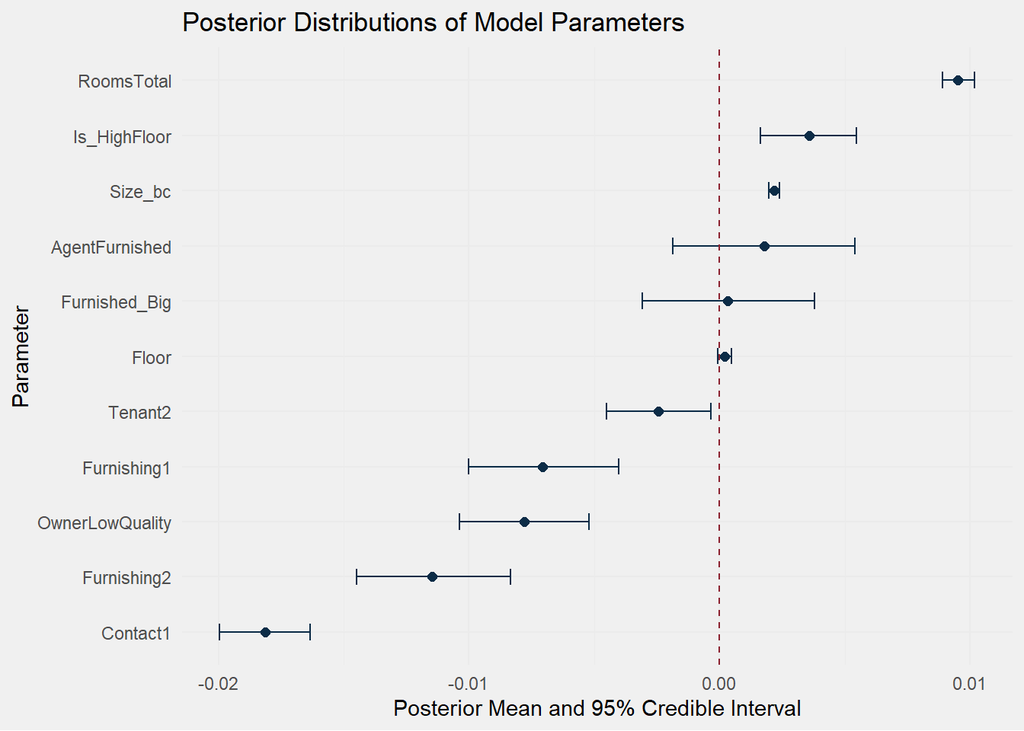

```r
plot_data <- summary_table %>%
  rename(
    parameter = Parameter,
    mean = Mean,
    ci_lower = q2.5,
    ci_upper = q97.5
  )  %>%
  filter(parameter != "Intercept")  # ⬅️ rimuove beta[1]

# Plotting Credible Intervals
ggplot(plot_data, aes(x = mean, y = reorder(parameter, mean))) +
  geom_point(color = "#0C2C47", size = 2) +
  geom_errorbarh(aes(xmin = ci_lower, xmax = ci_upper), height = 0.3, color = "#0C2C47") +
  geom_vline(xintercept = 0, linetype = "dashed", color = "#8C2230") +
  labs(
    x = "Posterior Mean and 95% Credible Interval",
    y = "Parameter",
    title = "Posterior Distributions of Model Parameters"
  ) +
  theme_minimal() +
  theme(
    plot.background = element_rect(fill = "#F0F0F0", color = NA),
    panel.background = element_rect(fill = "#F0F0F0", color = NA),
    legend.position = "none"
  )
```

**1. Significant Predictors**

**3. Non-Significant Predictors**

- **Furnished_Big (`beta[11]`)**
  - **Point Estimate:** 0.00034
  - **95% CI Estimate:** [–0.00307, 0.00376]
  - **Interpretation:** No significant effect — the combination of size and furnishing does not strongly influence rent in this model.
- **AgentFurnished (`beta[12]`)**
  - **Point Estimate:** 0.0017
  - **95% CI Estimate:** [–0.0018, 0.0052]
  - **Interpretation:** Small positive effect, but the credible interval includes 0, suggesting uncertainty.

# Frequentist Analysis

For the frequentist analysis, we will use a **Generalized Linear Mixed Model (GLMM)**. This model is suitable because, like the Bayesian hierarchical model, it can handle nested or grouped data and incorporate random effects to account for variability between different levels of the hierarchy. Using a GLMM allows for a direct comparison with the Bayesian approach.

In the following linear mixed-effects regression model, Rent_bc is the target variable the model aims to explain based on the following predictors:

Rent_bc ∼ Size_bc + Floor + RoomsTotal + Furnishing.Status + Tenant.Preferred + Area.Type + Point.of.Contact + OwnerLowQuality + Is_HighFloor + Furnished_Big + AgentFurnished + (1 | City)

The estimated coefficients will reflect the effect of each predictor on the dependent variable Rent_bc:

- A positive coefficient indicates that an increase in the value of the predictor is associated with an **increase in the rental price**, keeping the other predictors constant.
- A negative coefficient suggests that an increase in the predictor is associated with a **decrease in the rental price**.

The **p-value** measures the statistical significance of the coefficient: a low p-value (typically below 0.05) indicates that the predictor has a significant effect on Rent_bc and the corresponding coefficient is significantly different from zero. A high p-value implies that the predictor does not have a statistically significant impact on the rental price.

```r
# Frequentist model with City as random effect

glmm_model <- glmmTMB(
  Rent_bc ~
    Size_bc +
    Floor +
    RoomsTotal +
    Furnishing.Status +
    Tenant.Preferred +
    Area.Type +
    Point.of.Contact +
    OwnerLowQuality +
    Is_HighFloor +
    Furnished_Big +
    AgentFurnished +
    (1 | City),
  data = df_clean,
  family = gaussian()
)

summary(glmm_model)
```

```
##  Family: gaussian  ( identity )
## Formula:          Rent_bc ~ Size_bc + Floor + RoomsTotal + Furnishing.Status +
##     Tenant.Preferred + Area.Type + Point.of.Contact + OwnerLowQuality +
##     Is_HighFloor + Furnished_Big + AgentFurnished + (1 | City)
## Data: df_clean
##
##       AIC       BIC    logLik -2*log(L)  df.resid
##  -22888.8  -22772.6   11462.4  -22924.8      4694
##
## Random effects:
##
## Conditional model:
##  Groups   Name        Variance  Std.Dev.
##  City     (Intercept) 0.0003273 0.01809
##  Residual             0.0004478 0.02116
## Number of obs: 4712, groups:  City, 6
##
## Dispersion estimate for gaussian family (sigma^2): 0.000448
##
## Conditional model:
##                                    Estimate Std. Error z value Pr(>|z|)
## (Intercept)                       3.0795405  0.0168770  182.47  < 2e-16 ***
## Size_bc                           0.0021688  0.0001009   21.50  < 2e-16 ***
## Floor                             0.0002086  0.0001409    1.48 0.138736
## RoomsTotal                        0.0095043  0.0003072   30.93  < 2e-16 ***
## Furnishing.StatusSemi_Furnished  -0.0073814  0.0015270   -4.83 1.34e-06 ***
## Furnishing.StatusUnfurnished     -0.0121484  0.0015495   -7.84 4.49e-15 ***
## Tenant.PreferredBachelors_Family -0.0032169  0.0008952   -3.59 0.000326 ***
## Tenant.PreferredFamily           -0.0051486  0.0012662   -4.07 4.78e-05 ***
## Area.TypeCarpet_Area              0.0093184  0.0150099    0.62 0.534718
## Area.TypeSuper_Area               0.0075856  0.0149955    0.51 0.612955
## Point.of.ContactContact_Builder  -0.0353597  0.0212149   -1.67 0.095565 .
## Point.of.ContactContact_Owner    -0.0166940  0.0009897  -16.87  < 2e-16 ***
## OwnerLowQuality                  -0.0074586  0.0013018   -5.73 1.01e-08 ***
## Is_HighFloor                      0.0034213  0.0009719    3.52 0.000431 ***
## Furnished_Big                     0.0002357  0.0017385    0.14 0.892173
## AgentFurnished                    0.0014226  0.0018199    0.78 0.434400
## ---
## Signif. codes:  0 '***' 0.001 '**' 0.01 '*' 0.05 '.' 0.1 ' ' 1
```

## Frequentist Model Summary

These metrics observed from the summary suggest the model fits the data quite well, the *low residual variance* ($\sigma^2 = 0.000448$) indicates that the model explains most of the variability in rental prices, while the *relatively high log-likelihood* (11462.4) and *very low AIC (-22888.8)* and *BIC (-22772.6)* confirm a good balance between fit and model complexity. Additionally, the *random intercept variance for City (0.0003273)* shows that allowing for variability across cities captures meaningful group-level effects.

**1. Significant Predictors**

- **Size**
  - **Estimate:** 0.00216
  - **p-value:** < 0.001
  - **Interpretation:** Highly significant. Larger properties are associated with higher rental prices.
- **RoomsTotal**
  - **Estimate:** 0.00950
  - **p-value:** < 0.001
  - **Interpretation:** Highly significant. Properties with more rooms tend to command higher rent.
- **Furnishing.StatusSemi_Furnished**
  - **Estimate:** –0.00738
  - **p-value:** < 0.001
  - **Interpretation:** Highly significant. Semi-furnished properties are associated with slightly lower rents compared to fully furnished ones.
- **Furnishing.Status_Unfurnished**
  - **Estimate:** –0.01215
  - **p-value:** < 0.001
  - **Interpretation:** Highly significant. Unfurnished properties tend to have significantly lower rental prices.
- **Tenant.Preferred_Family**
  - **Estimate:** –0.00515
  - **p-value:** < 0.001
  - **Interpretation:** Significant. Preference for families is associated with a moderate decrease in rent.
- **Point.of.Contact_Contact_Owner**
  - **Point Estimate:** –0.01669
  - **p-value:** < 0.001
  - **Interpretation:** Highly significant. Contacting the owner directly is strongly associated with lower rent prices.
- **OwnerLowQuality**
  - **Estimate:** –0.00746
  - **p-value:** < 0.001
  - **Interpretation:** Highly significant. “Low quality” properties are associated with lower rent.
- **Is_HighFloor**
  - **Estimate:** 0.00342
  - **p-value:** 0.0004
  - **Interpretation:** Significant. Being on a high floor is associated with slightly higher rent.

**2. Marginally Significant Predictor**

- **Point.of.Contact_Contact_Builder**
  - **Estimate:** –0.03536
  - **p-value:** 0.0956
  - **Interpretation:** Marginally significant. May indicate lower rent when the contact is a builder, but the effect is uncertain.

**3. Non-Significant Predictors**

- **Floor**
  - **Estimate:** 0.00021
  - **p-value:** 0.139
  - **Interpretation:** Not significant. Floor level shows no meaningful effect on rent.
- **Furnished_Big**
  - **Estimate:** 0.00024
  - **p-value:** 0.892
  - **Interpretation:** Not significant. No clear effect from having a big, furnished unit.
- **AgentFurnished**
  - **Estimate:** 0.00142
  - **p-value:** 0.434
  - **Interpretation:** Not significant. Having a furnished unit through an agent does not appear to impact rent.

# Comparison of Bayesian and Frequentist

To quantitatively compare the predictive performance of the Bayesian (JAGS) and frequentist (GLMM) models, we computed two standard error metrics: **Root Mean Squared Error (RMSE)** and **Mean Absolute Error (MAE)**.

These metrics were calculated using the model predictions against the observed values of the transformed target variable `Rent_bc`. While RMSE emphasizes larger errors due to squaring, MAE provides a more general average of absolute deviations.

The results allow us to evaluate which model produces more accurate predictions, highlighting potential gains from including hierarchical structure and uncertainty estimation in the Bayesian framework. Both metrics are evaluated for the third model.

```r
# Predictions from the glmmTMB model
predictions_glmm <- predict(glmm_model, newdata = df_clean, type = "response")
true_values <- df_clean$Rent_bc

# Compute RMSE and MAE
rmse_glmm <- sqrt(mean((predictions_glmm - true_values)^2))
mae_glmm <- mean(abs(predictions_glmm - true_values))

cat("RMSE for the GLMM model:", rmse_glmm, "\n", "MAE for the GLMM model:", mae_glmm, "\n")
```

```
## RMSE for the GLMM model: 0.02114809
##  MAE for the GLMM model: 0.01585
```

```r
y_rep_matrix <- as.matrix(samples)[, grep("^y_rep\\[", colnames(as.matrix(samples)))]

# Average of posterior predictions
posterior_predictions <- colMeans(y_rep_matrix)
observed_values <- df_clean$Rent_bc

# Compute RMSE and MAE
rmse_jags <- sqrt(mean((posterior_predictions - observed_values)^2))
mae_jags <- mean(abs(posterior_predictions - observed_values))

cat("RMSE for the JAGS model:", rmse_jags, "\n", "MAE for the JAGS model:", mae_jags, "\n")
```

```
## RMSE for the JAGS model: 0.02120931
##  MAE for the JAGS model: 0.01588632
```

The performance metrics show that both models provide very similar results in predicting `Rent_bc`. These nearly identical values suggest that both the frequentist and Bayesian approaches achieve comparable predictive accuracy on this dataset. While the GLMM model performs slightly better in terms of RMSE and MAE, the difference is minimal.

This indicates that the added complexity of the Bayesian model in this case has not lead to substantial gains in prediction error, but may still offer advantages in interpretability and flexibility.

# Conclusion

In this project I created different version of bayesian hierarchical models, experimenting with different sets of predictorsm parameters and model structures and effects. After identifying the best-performing Bayesian model, we compared its results with those of a corresponding Frequentist model. Based on the results obtained from both the Bayesian and Frequentist models, we can draw several conclusions regarding the factors influencing rental prices:

Both the approaches resulted in *very similar predictive performance*, with nearly identical RMSE and MAE values, indicating that either method can be effectively used for rental price estimation in this context. However, the Bayesian framework offers the added advantage of *probabilistic interpretability* and *flexible hierarchical modeling*.